# A Julia toolkit for species distribution data

Author

Affiliation

Timothée Poisot

Université de Montréal

Abstract

(1) Species distribution modeling requires to handle varied types of data, and benefits from an integrated approach to programming. (2) We introduce **SpeciesDistributionToolkit**, a **Julia** package aiming to facilitate the production of species distribution models. It covers various steps of the data collection and analysis process, extending to the development of interfaces for integration of additional functionalities. (3) By relying on semantic versioning and strong design choices on modularity, we expect that this package will lead to improved reproducibility and long-term maintainability. (4) We illustrate the functionalities of the package through several case studies, accompanied by reproducible code.

Keywords

species distribution models, biogeography, occurrence data, land use, climatic data, pseudo-absences

# Introduction

Species Distribution Models (SDMs) are one of the most effective predictive approach to study the global distribution of biodiversity (Elith and Leathwick 2009). The training and evaluation of a SDM requires many steps, governing both its design and reporting (Zurell et al. 2020) and ultimate use and interpretation (Araújo et al. 2019). In the recent years, there has been an increase in the number of software packages and tools to assist ecologists with the development of species distribution models.

Because the practice of species distribution modeling and analysis usually involve many different data types, tools that can provide an integrated environment are important: many existing packages have been designed independently, and therefore may suffer when it comes to interoperability. In this manuscript, we present **SpeciesDistributionToolkit** (abbreviated as **SDT**), a meta-package for the **Julia** programming language, offering an integrated environment for the retrieval, formatting, and interpretation of data relevant to the modeling of species distributions.

As Kass et al. (2024) point out, this increase in the diversity of packages (most of them in the **R** language) is a good thing, as it can accommodate multiple workflows, and contributes to the adoption of good practices in the field. Yet, Kellner, Doser, and Belant (2025) highlight that about 20% of publications for abundance or distribution models are not reproducible because of issues in package dependencies. A leading design consideration for **SDT** was to prevent this issue from happening, both by relying on strict semantic versioning, but also through the use of interfaces rather dependencies between the components of **SDT**.

The **SDT** package is now used as part of the BON-in-a-Box project (Griffith et al. 2024), which seeks to facilitate the calculation and reporting of biodiversity indicators supporting the Kunming-Montréal Global Biodiversity Framework, to remove barriers to biodiversity data analysis (Gonzalez et al. 2023). In this manuscript, we describe (i) the high-level functionalities of the package, (ii) core design principles that facilitate long-term maintenance and development, and (iii) illustrative case studies with fully reproducible Jupyter notebooks.

# Application description

**SpeciesDistributionToolkit** is released as a package for the **Julia** programming language (Bezanson et al. 2017), licensed under the open-source initiative approved MIT license. It has evolved from a previous collection of packages to handle GBIF data (Dansereau and Poisot 2021), and now provides extended functionalities and improved performances. The package is registered in the **Julia** package repository and can be downloaded and installed anonymously. It is compatible with version 1.8 and above. The full source and complete edition history is available at [`https://github.com/PoisotLab/SpeciesDistributionToolkit.jl`](https://github.com/PoisotLab/SpeciesDistributionToolkit.jl). This page additionally has a link to the documentation, containing a full reference for the package functions, a series of briefs how-to examples, and longer vignettes showcasing more integrative examples.

## Component packages

An overview of the **SDT** package is given in Figure 1. The project is organized as a “monorepo”, in which multiple packages live. This allows expanding the scope of the package by moving functionalities into new component packages, without complexifying the installation process. As **SDT** is registered in the **Julia** package repository, it can be installed by using `add SpeciesDistributionToolkit` when in package mode at the **Julia** prompt.

When loading the **SDT** package with `using SpeciesDistributionToolkit`, all component packages are automatically and transparently loaded. Therefore, users do not need to know where a specific method or function resides to use it. In the next section, we discuss how this modular design ensure that we can grow the functionality of the toolkit over time, while maintaining strict backward compatibility *and* allowing full reproducibility of an analysis.

[figure not shown]

Figure 1: Overview of the packages included in **SpeciesDistributionToolkit**. The packages are color-coded by intended use, and their more specific content is presented in the main text. Note that because the package relies on *interfaces* to facilitate code interoperability, there are only three dependency relationships.

The **SDT** package primarily provides integration between the other packages, through the mechanism of method overloading, allowing to efficiently join packages together (Roesch et al. 2023). Additional functionalities that reside in the top-level package are the generation of pseudo-absences inspired by Barbet-Massin et al. (2012), access to the `gadm.org` database, handling of polygon data and zonal statistics, and various quality of life methods. Because of the modular nature of the code, any of these functions can be transparently moved to their own packages in the future.

The **SimpleSDMLayers** package offers a series of types to represent raster data in various projections, and a series of functions to operate on these layers. This package provides the main data representation for most functionalities that **SDT** supports, and handles saving and loading data.

The **OccurrencesInterface** is a light-weight package to provide a common interface for occurrence data. It implements abstract and concrete types to define a single occurrence and a collection thereof, and a series of methods allowing any occurrence data provider or data representation to become fully interoperable with the rest of **SDT**. All **SDT** methods that handle occurrence data do so through the **OccurrencesInterface** interface, allowing future data sources to be integrated without the need for new code.

The **GBIF** package offers access to the `gbif.org` streaming API (GBIF: The Global Biodiversity Information Facility 2025), including the ability to retrieve, filter, and restart downloads. Although this package returns a rich data representation for occurrence data, all the objects it returns adhere to the **OccurrencesInterface** interface.

**SimpleSDMDatasets** implements an interface to retrieve and locally store raster data, which can be extended by users to support additional data sources. In addition, it offers access to a series of data sources, including the biodiversity mapping project (Jenkins, Pimm, and Joppa 2013), the EarthEnv collection for land cover (Tuanmu and Jetz 2014) and habitat heterogeneity (Tuanmu and Jetz 2015), Copernicus land cover 100m data (Buchhorn et al. 2020), the PaleoClim (Brown et al. 2018) data, the WorldClim 1 and 2 data (Fick and Hijmans 2017) and their projections under various RCPs and SSP, and part of the CHELSA 1 and 2 data (Karger et al. 2017) and their projections under various RCPs and SSPs.

**Phylopic** offers a wrapper around the `phylopic.org` API to download silhouettes for taxonomic entities. It also provides utilities for citation of the downloaded images. Its functionalities are similar to the **rphylopic** package (Gearty and Jones 2023).

The **Fauxcurrences** packages is inspired by the work of Osborne et al. (2022), and allows generating a series of simulated occurrence data that have the same statistical structure as observed ones. The package supports multi-species data, with user-specified relative weight of intra and inter-specific distances conservation.

The **SDeMo** package is aimed at providing tools to use as part of training and education material on species distribution modeling. By providing a series of data transformation (PCA, Whitening, z-score) and classifiers (BIOCLIM, Naive Bayes, and decision trees), it offers the basic elements to demonstrate training and evaluation of SDMs, as well as techniques related to ensembles and bagging. In addition, to promote the use of interpretable techniques, the package supports regular (Elith et al. 2005) and inflated (Zurell, Elith, and Schröder 2012) partial responses, as well as the calculation and mapping of Shapley values (Wadoux, Saby, and Martin 2023; Mesgaran, Cousens, and Webber 2014), and the generation of counterfactuals Karimi et al. (2019).

## Integration with other packages

The **SDT** package benefits from close integration with other packages in the **Julia** universe. Notably, this includes **Makie** (and all related backends) for plotting and interactive data visualisation, where usual plot types are overloaded for both layer and occurrence data. Most data handled by **SDT** can be exported using the **Tables** interface, which allows data to be consumed by other packages like **DataFrames** and **MLJ**, or directly saved as csv files.

Interfaces internal to **Julia** are also implemented whenever they make sense. In particular, **SimpleSDMLayers** objects behave like arrays, are iterable, and broadcastable; objects from **OccurrencesInterface** behave as arrays and are similarly iterable. The **SDeMo** package relies on part of the **StatsAPI** interface, allowing to easily define new data transformation and classifier types to support additional features.

Achieving integration with other packages through method overloading and the adherence to well-established interfaces is important, as it increases the chances that additional functionalities external to **SDT** can be used directly or fully supported with minimal addition of code.

# Illustrative case studies

In this section, we provide a series of case studies, meant to illustrate the use of the package. The on-line documentation offers longer tutorials, as well as a series of how-to vignettes to illustrate the full scope of what the package allows. The code for each of these case studies is available as fully independent Jupyter notebooks, forming the supplementary material of this article. The example we use throughout is the distribution of *Akodon montensis* (Rodentia, family Cricetidae), a host or orthohantaviruses (Burgos et al. 2021; Owen et al. 2010), in Paraguay. As the notebooks accompanying this article cover the full code required to run these case studies, we do not present code snippets in the main text, and instead focus on explaining which component packages are used in each example.

## Using data from GBIF

To illustrate the interactions between the component packages, we provide a simple illustration (Supp. Mat. 1) where we (i) request occurrence data using the **GBIF** package, (ii) download the silhouette of the species through **Phylopic**, and (iii) extract temperature and precipitation data at the points of occurrence. The results are presented in Figure 2. The full notebook includes information about basic operations on raster data, as well as extraction of data based on occurrence records.

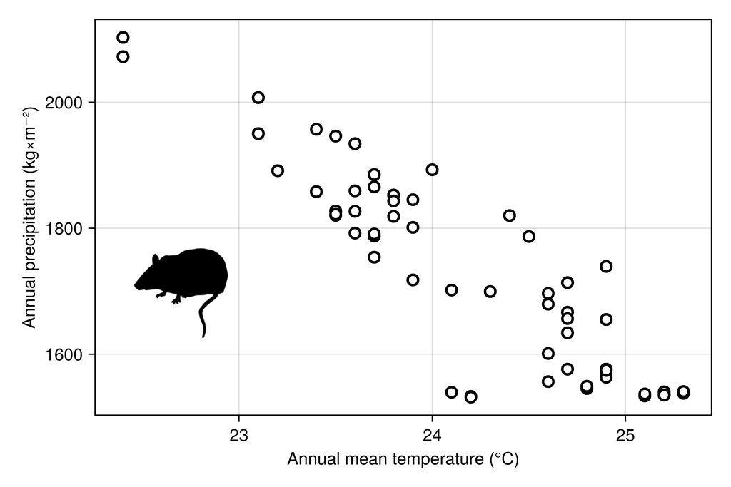

Figure 2: Relationship between temperature and precipitation (BIO1 and BIO12) at each georeferenced occurrence known to GBIF for *Akodon montensis*. The code to produce this figure is available as Supp. Mat. 1.

In practice, although the data are retrieved using the **GBIF** package, they are used internally by **SDT** through the **OccurrencesInterface** package. This package defines a small convention to handle georeferenced occurrence data, and allows to transparently integrate additional occurrence sources. By defining five methods for a custom data type, users can plug-in any occurrence data source and enjoy full compatibility with the entire **SDT** functionalities.

## Landcover consensus map

In this case study (Supp. Mat. 2), we retrieve the land cover data from Tuanmu and Jetz (2014), clip them to a GeoJSON polygon describing the country of Paraguay (**SDT** can download data directly from `gadm.org`), and apply the `mosaic` operation to figure out which class is the most locally abundant. This case study uses the **SimpleSDMDatasets** package to download (and locally cache) the raster data, as well as the **SimpleSDMLayers** package to provide basic utility functions on raster data. The results are presented in Figure 3.

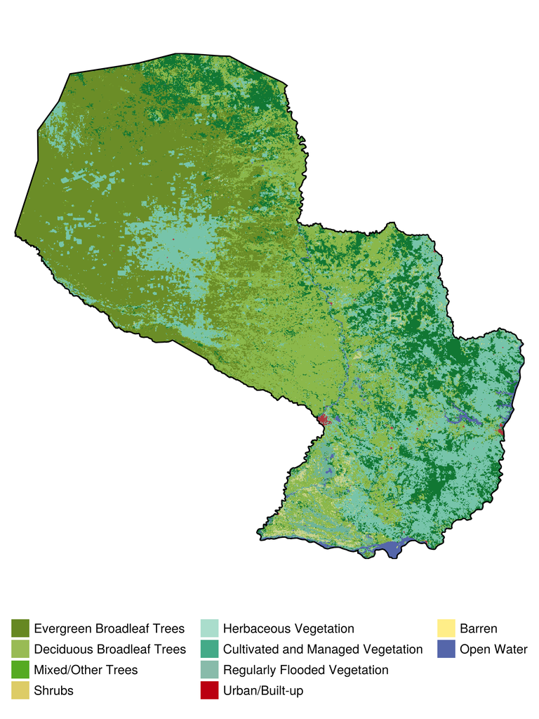

Figure 3: Land cover consensus (defined as the class with the strongest local representation) in the country of Paraguay. Only the classes that were most abundant in at least one pixel are represented. The code to produce this ﬁgure is available as Supp. Mat. 2.

When first downloading data through **SimpleSDMDatasets**, they will be stored locally for future use. When the data are requested a second time, they are read directly from the disk, speeding up the process massively. Note that the location of the data is (i) standardized by the package itself, making the file findable to humans, and (ii) changeable by the user to, *e.g.*, store the data within the project folder rather than in a central location. As much as possible, **SDT** will only read the part of the raster data that is required given the region of interest to the user. This is done by providing additional context in the form of a bounding box (in WGS84, regardless of the underlying raster data projection). **SDT** has methods to calculate the bounding box for all the objects it supports.

## Training a species distribution model

In this case study, we illustrate the integration of **SDeMo** and **SimpleSDMLayers** to train a species distribution model. We specifically train a rotation forest (Bagnall et al. 2018), an homogeneous ensemble of PCA followed by decision trees. The results are presented in Figure 4. The model is built by selecting an optimal suite of BioClim variables, then predicted in space, and the resulting predicted species range is finally clipped by the elevational range observed in the occurrence data.

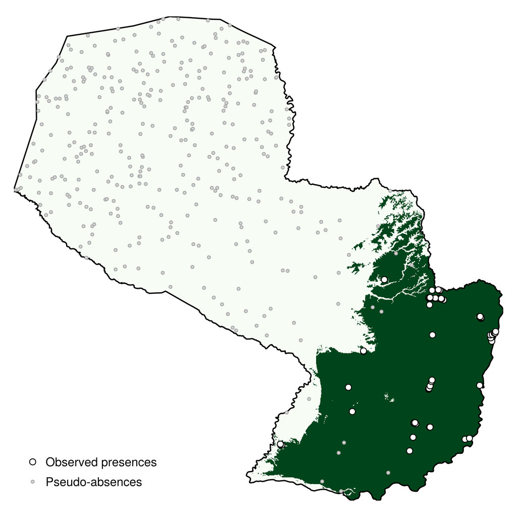

Figure 4: Predicted range of *Akodon montensis* in Paraguay based on a rotation forest trained on GBIF occurrences and the BioClim variables. The predicted range is clipped to the elevational range of the species. The code to produce this ﬁgure is available as Supp. Mat. 3.

The full notebook (Supp. Mat. 3) has additional information on routines for variable selection, stratified cross-validation, as well as the construction of the ensemble from a single PCA and decision tree. In addition, Supp. Mat. 3 presents the partial responses and Shapley values for the most important predictor.

## Distribution of a virtual species

[figure not shown]

Because the layers used by **SDT** are broadcastable, we can rapidly apply a function (here, the logistic response to the environmental covariate) to each layer, and then multiply the suitabilities together. The last step is facilitated by the fact that most basic arithmetic operations are defined for layers, allowing for example to add, multiply, substract, and divide them by one another.

# Conclusion

We have presented **SpeciesDistributionToolkit**, a package for the **Julia** programming language aiming to facilitate the collection, curation, analysis, and visualisation of data commonly used in species distribution modeling. Through the use of interfaces and a modular design, we have made this package robust to changes, easy to add functionalities to, and well integrated to the rest of the **Julia** ecosystem. All code for the case studies can be found in Supp. Mat. 1-4.

Plans for active development of the package are focused on (i) additional techniques for pseudo-absence generations, likely leading to their separate component package, (ii) full compatibility with the **MultivariateStatistics** and **Clustering** packages for transformation and aggregation, and (iii) additional **SDeMo** functionalities to allow cross-validation techniques with biological relevant structure (Roberts et al. 2017).

**Acknowledgements:** TP is funded by an NSERC Discovery grant, a Discovery Acceleration Supplement grant, and a Wellcome Trust grant (223764/Z/21/Z).

## References

Araújo, Miguel B, Robert P Anderson, A Márcia Barbosa, Colin M Beale, Carsten F Dormann, Regan Early, Raquel A Garcia, et al. 2019. “Standards for Distribution Models in Biodiversity Assessments.” *Science Advances* 5 (January): eaat4858. https://doi.org/10.1126/sciadv.aat4858.

Bagnall, A, M Flynn, J Large, J Line, A Bostrom, and G Cawley. 2018. “Is Rotation Forest the Best Classifier for Problems with Continuous Features?” *arXiv [Cs.LG]*, September.

Barbet-Massin, Morgane, Frédéric Jiguet, Cécile Hélène Albert, and Wilfried Thuiller. 2012. “Selecting Pseudo‐absences for Species Distribution Models: How, Where and How Many?: How to Use Pseudo-Absences in Niche Modelling?” *Methods in Ecology and Evolution* 3 (April): 327–38. https://doi.org/10.1111/j.2041-210x.2011.00172.x.

Bezanson, Jeff, Alan Edelman, Stefan Karpinski, and Viral B Shah. 2017. “Julia: A Fresh Approach to Numerical Computing.” *SIAM Review. Society for Industrial and Applied Mathematics* 59 (January): 65–98. https://doi.org/10.1137/141000671.

Brown, Jason L, Daniel J Hill, Aisling M Dolan, Ana C Carnaval, and Alan M Haywood. 2018. “PaleoClim, High Spatial Resolution Paleoclimate Surfaces for Global Land Areas.” *Scientific Data* 5 (November): 180254. https://doi.org/10.1038/sdata.2018.254.

Buchhorn, Marcel, Bruno Smets, Luc Bertels, Bert De Roo, Myroslava Lesiv, Nandin-Erdene Tsendbazar, Martin Herold, and Steffen Fritz. 2020. “Copernicus Global Land Service: Land Cover 100m: Collection 3: Epoch 2019: Globe.” Zenodo. https://doi.org/10.5281/ZENODO.3939050.

Burgos, E F, M V Vadell, C M Bellomo, V P Martinez, O D Salomon, and I E Gómez Villafañe. 2021. “First Evidence of Akodon-Borne Orthohantavirus in Northeastern Argentina.” *EcoHealth* 18 (December): 429–39. https://doi.org/10.1007/s10393-021-01564-6.

Dansereau, Gabriel, and Timothée Poisot. 2021. “SimpleSDMLayers.jl and GBIF.jl: A Framework for Species Distribution Modeling in Julia.” *Journal of Open Source Software* 6 (January): 2872. https://doi.org/10.21105/joss.02872.

Elith, Jane, Simon Ferrier, Falk Huettmann, and John Leathwick. 2005. “The Evaluation Strip: A New and Robust Method for Plotting Predicted Responses from Species Distribution Models.” *Ecological Modelling* 186 (August): 280–89. https://doi.org/10.1016/j.ecolmodel.2004.12.007.

Elith, Jane, and John R Leathwick. 2009. “Species Distribution Models: Ecological Explanation and Prediction Across Space and Time.” *Annual Review of Ecology, Evolution, and Systematics* 40 (December): 677–97. https://doi.org/10.1146/annurev.ecolsys.110308.120159.

Fick, Stephen E, and Robert J Hijmans. 2017. “WorldClim 2: New 1‐km Spatial Resolution Climate Surfaces for Global Land Areas: NEW CLIMATE SURFACES FOR GLOBAL LAND AREAS.” *International Journal of Climatology: A Journal of the Royal Meteorological Society* 37 (October): 4302–15. https://doi.org/10.1002/joc.5086.

GBIF: The Global Biodiversity Information Facility. 2025. “*What Is GBIF?*” 2025.

Gearty, William, and Lewis A Jones. 2023. “Rphylopic: An R Package for Fetching, Transforming, and Visualising PhyloPic Silhouettes.” *Methods in Ecology and Evolution* 14 (November): 2700–2708. https://doi.org/10.1111/2041-210x.14221.

Gonzalez, Andrew, Petteri Vihervaara, Patricia Balvanera, Amanda E Bates, Elisa Bayraktarov, Peter J Bellingham, Andreas Bruder, et al. 2023. “A Global Biodiversity Observing System to Unite Monitoring and Guide Action.” *Nature Ecology & Evolution*, August, 1–5. https://doi.org/10.1038/s41559-023-02171-0.

Griffith, Jory, Jean-Michel Lord, Michael D Catchen, Maria Isabel Arce-Plata, Manuel Fernandez Galvez Bohorquez, Matusan Chandramohan, María Camilla Diaz-Corzo, et al. 2024. “BON in a Box: An Open and Collaborative Platform for Biodiversity Monitoring, Indicator Calculation, and Reporting,” October. https://doi.org/10.32942/X2M320.

Hirzel, A H, V Helfer, and F Metral. 2001. “Assessing Habitat-Suitability Models with a Virtual Species.” *Ecological Modelling* 145 (November): 111–21. https://doi.org/10.1016/s0304-3800(01)00396-9.

Jenkins, Clinton N, Stuart L Pimm, and Lucas N Joppa. 2013. “Global Patterns of Terrestrial Vertebrate Diversity and Conservation.” *Proceedings of the National Academy of Sciences of the United States of America* 110 (July): E2602–10. https://doi.org/10.1073/pnas.1302251110.

Karger, Dirk Nikolaus, Olaf Conrad, Jürgen Böhner, Tobias Kawohl, Holger Kreft, Rodrigo Wilber Soria-Auza, Niklaus E Zimmermann, H Peter Linder, and Michael Kessler. 2017. “Climatologies at High Resolution for the Earth’s Land Surface Areas.” *Scientific Data* 4 (September): 170122. https://doi.org/10.1038/sdata.2017.122.

Karimi, Amir-Hossein, Gilles Barthe, Borja Balle, and Isabel Valera. 2019. “Model-Agnostic Counterfactual Explanations for Consequential Decisions.” *arXiv [Cs.LG]*, May.

Kass, Jamie M, Adam B Smith, Dan L Warren, Sergio Vignali, Sylvain Schmitt, Matthew E Aiello-Lammens, Eduardo Arlé, et al. 2024. “Achieving Higher Standards in Species Distribution Modeling by Leveraging the Diversity of Available Software.” *Ecography*, November. https://doi.org/10.1111/ecog.07346.

Kellner, Kenneth F, Jeffrey W Doser, and Jerrold L Belant. 2025. “Functional R Code Is Rare in Species Distribution and Abundance Papers.” *Ecology* 106 (January): e4475. https://doi.org/10.1002/ecy.4475.

Kemerer, Chris F. 1987. “An Empirical Validation of Software Cost Estimation Models.” *Communications of the ACM* 30 (May): 416–29. https://doi.org/10.1145/22899.22906.

Legendre, Pierre, and Miquel De Cáceres. 2013. “Beta Diversity as the Variance of Community Data: Dissimilarity Coefficients and Partitioning.” *Ecology Letters* 16 (August): 951–63. https://doi.org/10.1111/ele.12141.

Leroy, Boris, Christine N Meynard, Céline Bellard, and Franck Courchamp. 2016. “Virtualspecies, an R Package to Generate Virtual Species Distributions.” *Ecography* 39 (June): 599–607. https://doi.org/10.1111/ecog.01388.

Mesgaran, Mohsen B, Roger D Cousens, and Bruce L Webber. 2014. “Here Be Dragons: A Tool for Quantifying Novelty Due to Covariate Range and Correlation Change When Projecting Species Distribution Models.” *Diversity & Distributions* 20 (October): 1147–59. https://doi.org/10.1111/ddi.12209.

Osborne, Owen G, Henry G Fell, Hannah Atkins, Jan van Tol, Daniel Phillips, Leonel Herrera-Alsina, Poppy Mynard, et al. 2022. “Fauxcurrence: Simulating Multi‐species Occurrences for Null Models in Species Distribution Modelling and Biogeography.” *Ecography* 2022 (July): e05880. https://doi.org/10.1111/ecog.05880.

Owen, Robert D, Douglas G Goodin, David E Koch, Yong-Kyu Chu, and Colleen B Jonsson. 2010. “Spatiotemporal Variation in Akodon Montensis (Cricetidae: Sigmodontinae) and Hantaviral Seroprevalence in a Subtropical Forest Ecosystem.” *Journal of Mammalogy* 91 (April): 467–81. https://doi.org/10.1644/09-MAMM-A-152.1.

Roberts, David R, Volker Bahn, Simone Ciuti, Mark S Boyce, Jane Elith, Gurutzeta Guillera-Arroita, Severin Hauenstein, et al. 2017. “Cross-Validation Strategies for Data with Temporal, Spatial, Hierarchical, or Phylogenetic Structure.” *Ecography* 40 (August): 913–29. https://doi.org/10.1111/ecog.02881.

Roesch, Elisabeth, Joe G Greener, Adam L MacLean, Huda Nassar, Christopher Rackauckas, Timothy E Holy, and Michael P H Stumpf. 2023. “Julia for Biologists.” *Nature Methods* 20 (May): 655–64. https://doi.org/10.1038/s41592-023-01832-z.

Tuanmu, Mao-Ning, and Walter Jetz. 2014. “A Global 1‐km Consensus Land‐cover Product for Biodiversity and Ecosystem Modelling: Consensus Land Cover.” *Global Ecology and Biogeography: A Journal of Macroecology* 23 (September): 1031–45. https://doi.org/10.1111/geb.12182.

———. 2015. “A Global, Remote Sensing‐based Characterization of Terrestrial Habitat Heterogeneity for Biodiversity and Ecosystem Modelling: Global Habitat Heterogeneity.” *Global Ecology and Biogeography: A Journal of Macroecology* 24 (November): 1329–39. https://doi.org/10.1111/geb.12365.

Van Looveren, Arnaud, and Janis Klaise. 2019. “Interpretable Counterfactual Explanations Guided by Prototypes.” *arXiv [Cs.LG]*, July.

Wadoux, Alexandre M J-C, Nicolas P A Saby, and Manuel P Martin. 2023. “Shapley Values Reveal the Drivers of Soil Organic Carbon Stock Prediction.” *SOIL* 9 (January): 21–38. https://doi.org/10.5194/soil-9-21-2023.

Zurell, Damaris, Jane Elith, and Boris Schröder. 2012. “Predicting to New Environments: Tools for Visualizing Model Behaviour and Impacts on Mapped Distributions.” *Diversity & Distributions* 18 (June): 628–34. https://doi.org/10.1111/j.1472-4642.2012.00887.x.

Zurell, Damaris, Janet Franklin, Christian König, Phil J Bouchet, Carsten F Dormann, Jane Elith, Guillermo Fandos, et al. 2020. “A Standard Protocol for Reporting Species Distribution Models.” *Ecography* 43 (September): 1261–77. https://doi.org/10.1111/ecog.04960.